# Networks: structure, evolution & processes

**Internet Analytics - Lab 2**

**Group:** *Q*

**Names:**

- *Berkay Güler*
- *Luka Secilmis*
- *Thomas Ecabert*
- *Aymeric Bacuet*

## 2.4 PageRank

### 2.4.1 Random Surfer Model

#### Exercise 2.12

```python
import networkx as nx
import matplotlib.pyplot as plt
import numpy as np
import random
import csv
%matplotlib inline

import sys
sys.setrecursionlimit(600000)
```

First we load and visualize the first toy network. This network consists of two sub-graphs

```
Number of nodes:  8
Number of edges:  10
```

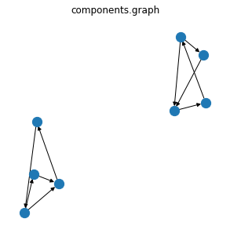

```python
# read the graph data into a directed graph structure
g = nx.read_adjlist('../data/components.graph', create_using=nx.DiGraph())

print('Number of nodes: ', g.number_of_nodes())
print('Number of edges: ', g.number_of_edges())

plt.figure(figsize=(5, 5))
plt.title("components.graph")
nx.draw(g, node_size=150)
plt.show()
```

Load and visualize the other toy network. This network includes a dangling node.

```
Number of nodes:  5
Number of edges:  7
```

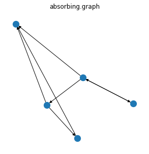

```python
# path for components.graph
network_path_2 = '../data/absorbing.graph'

# read the graph data into a directed graph structure
g_2 = nx.read_adjlist(network_path_2, create_using=nx.DiGraph())

print('Number of nodes: ', g_2.number_of_nodes())
print('Number of edges: ', g_2.number_of_edges())

plt.figure(figsize=(5, 5))
plt.title("absorbing.graph")
nx.draw(g_2, node_size=150)
plt.show()
```

```python
def normalize_page_rank(page_rank_matrix):

    """Function to normalize the page rank results"""

    return page_rank_matrix / np.sum(page_rank_matrix)

def average_page_rank_scores(arr_of_matrices):
    """Function to average page rank scores for n iteration"""
    return np.mean(arr_of_matrices, axis=0)
```

```python
def surf(node, page_rank_matrix, network, thr):
    """
    Recursively surf over pages for number of thr times, as explained in the lab manual.
    """
    global count
    if count >= thr:
        return

    page_rank_matrix[int(node)] += 1
    count += 1

    try:
        out_edges = list(network.out_edges(node))[0]
    except:
        surf(node, page_rank_matrix, network, thr)
        return

    next_node = random.choice(out_edges)
    surf(next_node, page_rank_matrix, network, thr)
```

### Random surfer model on components.graph

In components graph, there are two groups or sub network between which no edge exists. Hence, depending on the start node for the random surfer model, the visited pages belong only to either of these networks.

Below is displayed 15 models run each with 3000 total page visit.

```python
# database to store random surf scores of pages for different graphs and surf models
random_surf_data = {}
```

```python
number_of_surfs = 3000

# number of times the simulation will run.
N = 15

# array to store probabilities of visiting each page after a random surf of number_of_surfs times
page_rank_scores = []

# select different starting nodes from the first toy network
for i in range(N):
    # initialize matrix to 0 for each round.
    page_rank = np.zeros((len(g.nodes())), dtype = np.int32)

    # count the number of surfs so far
    count = 0

    # choose a starting page uniformly randomly
    random_page = random.choice(list(g.nodes()))

    # start surfing recursively for number_of_surfs times
    surf(random_page, page_rank, g, number_of_surfs)

    page_rank_scores.append(normalize_page_rank(page_rank))
    print(f"*****Search {i + 1}*******")
    print('Started at node:', random_page)
    print('Number of visits of each page:', page_rank)
    print('Approximation for the probability of visiting each page given the starting node and number of total visits:\n', normalize_page_rank(page_rank), "\n\n\n")

page_rank_scores_arr = np.array(page_rank_scores)

# average the probabilites for each page after N round
ranks = average_page_rank_scores(page_rank_scores_arr)

print(f"Average scores for 15 iteration is: {ranks} \n" )
random_surf_data['Components Graph Basic Random Surf'] = [ranks]
random_surf_data['Components Graph Basic Random Surf'].append(len(g.nodes()))
random_surf_data['Components Graph Basic Random Surf'].append(page_rank_scores[0])
```

```
*****Search 1*******
Started at node: 7
Number of visits of each page: [  0   0   0   0 714 762 761 763]
Approximation for the probability of visiting each page given the starting node and number of total visits:
 [0.         0.         0.         0.         0.238      0.254
 0.25366667 0.25433333]



*****Search 2*******
Started at node: 6
Number of visits of each page: [  0   0   0   0 712 744 751 793]
Approximation for the probability of visiting each page given the starting node and number of total visits:
 [0.         0.         0.         0.         0.23733333 0.248
 0.25033333 0.26433333]



*****Search 3*******
Started at node: 0
Number of visits of each page: [1026  965 1009    0    0    0    0    0]
Approximation for the probability of visiting each page given the starting node and number of total visits:
 [0.342      0.32166667 0.33633333 0.         0.         0.
 0.         0.        ]



*****Search 4*******
Started at node: 1
Number of visits of each page: [1005 1040  955    0    0    0    0    0]
Approximation for the probability of visiting each page given the starting node and number of total visits:
 [0.335      0.34666667 0.31833333 0.         0.         0.
 0.         0.        ]



*****Search 5*******
Started at node: 7
Number of visits of each page: [  0   0   0   0 735 728 753 784]
Approximation for the probability of visiting each page given the starting node and number of total visits:
```

[output cut: 81 more lines]

```
 0.26633333 0.254     ]



*****Search 15*******
Started at node: 6
Number of visits of each page: [  0   0   0   0 756 755 729 760]
Approximation for the probability of visiting each page given the starting node and number of total visits:
 [0.         0.         0.         0.         0.252      0.25166667
 0.243      0.25333333]



Average scores for 15 iteration is: [0.11304444 0.1098     0.11048889 0.         0.16346667 0.16535556
 0.17055556 0.16728889]
```

### Random surfer model on absorbing.graph

In absorbing graph, there is a dangling node which does not have an outgoing edge. Thus when our random surf model reaches a dangling node, it remains stuck at that node.

Below is displayed 15 models run each with 3000 total page visit.

```python
number_of_surfs = 3000
N = 15

page_rank_scores = []

# select different starting nodes from the first toy network
for i in range(N):
    page_rank = np.zeros((len(g_2.nodes())), dtype = np.int32)
    count = 0 # count the number of surfs so far
    random_page = random.choice(list(g_2.nodes()))
    surf(random_page, page_rank, g_2, number_of_surfs)
    page_rank_scores.append(normalize_page_rank(page_rank))
    print(f"*****Search {i + 1}*******")
    print('Started at node:', random_page)
    print('Number of visits of each page:', page_rank)
    print('Approximation for the probability of visiting each page given the starting node and number of total visits:\n', normalize_page_rank(page_rank), "\n\n\n")

page_rank_scores_arr = np.array(page_rank_scores)
ranks = average_page_rank_scores(page_rank_scores_arr)

print(f"Average scores for 15 iteration is: {ranks} \n" )

random_surf_data['Absorbing Graph Basic Random Surf'] = [ranks]
random_surf_data['Absorbing Graph Basic Random Surf'].append(len(g_2.nodes()))
random_surf_data['Absorbing Graph Basic Random Surf'].append(page_rank_scores[0])
```

```
*****Search 1*******
Started at node: 1
Number of visits of each page: [   0 3000    0    0    0]
Approximation for the probability of visiting each page given the starting node and number of total visits:
 [0. 1. 0. 0. 0.]



*****Search 2*******
Started at node: 4
Number of visits of each page: [   0 2999    0    0    1]
Approximation for the probability of visiting each page given the starting node and number of total visits:
 [0.00000000e+00 9.99666667e-01 0.00000000e+00 0.00000000e+00
 3.33333333e-04]



*****Search 3*******
Started at node: 3
Number of visits of each page: [   1 2995    0    4    0]
Approximation for the probability of visiting each page given the starting node and number of total visits:
 [3.33333333e-04 9.98333333e-01 0.00000000e+00 1.33333333e-03
 0.00000000e+00]



*****Search 4*******
Started at node: 2
Number of visits of each page: [   2 2995    1    2    0]
Approximation for the probability of visiting each page given the starting node and number of total visits:
 [6.66666667e-04 9.98333333e-01 3.33333333e-04 6.66666667e-04
 0.00000000e+00]



*****Search 5*******
Started at node: 0
Number of visits of each page: [   1 2999    0    0    0]
Approximation for the probability of visiting each page given the starting node and number of total visits:
 [3.33333333e-04 9.99666667e-01 0.00000000e+00 0.00000000e+00
```

[output cut: 77 more lines]

```
Approximation for the probability of visiting each page given the starting node and number of total visits:
 [0.    0.999 0.    0.    0.001]



*****Search 15*******
Started at node: 4
Number of visits of each page: [   0 2997    0    0    3]
Approximation for the probability of visiting each page given the starting node and number of total visits:
 [0.    0.999 0.    0.    0.001]



Average scores for 15 iteration is: [2.44444444e-04 9.99177778e-01 8.88888889e-05 2.00000000e-04
 2.88888889e-04]
```

#### Exercise 2.13

With a small modification to the initial function, after reaching a dangling node we choose the next page uniformly randomly over all possible pages. Besides, at each iteration, with small probability (called the damping factor), we start surfing from a new node chosen uniformly at random.

```python
def damped_surf(node, page_rank_matrix, network, thr):
    """Recursively surf over pages for number of thr times, as explained in the lab manual."""

    global count

    if count >= thr:
        return

    page_rank_matrix[int(node)] += 1
    count += 1

    random_node_prob = np.random.rand()
    # with probability 0.85 continue from the current page
    if random_node_prob > 0.15:

        try:
            out_edges = list(network.out_edges(node))[0]
        except:
            # if reached dangling node randomly choose a new node
            next_node = random.choice(list(network.nodes()))
            damped_surf(next_node, page_rank_matrix, network, thr)
            return

        next_node = random.choice(out_edges)
        damped_surf(next_node, page_rank_matrix, network, thr)
    # with prob. 0.15 jump to a random page
    else:
        next_node = random.choice(list(network.nodes()))
        damped_surf(next_node, page_rank_matrix, network, thr)
```

#### Page Rank algo on components.graph*

- Random surf model makes more intuitive sense when modified with damping factor and after avoiding dangling node.
- The probability for a random surfer be present in node is better approximated with modified random surfer for the following intuitive reasons:
  - On the web when a user is present on a web page without outgoing links, that user that user does not stay in that page forever.
  - Users do not only choose a website from the links in the pages that they are already surfing on but they can also use keywords to visit new pages.

```python
number_of_surfs = 3000

page_rank_scores = []

# select different starting nodes from the first toy network
for i in range(15):
    page_rank = np.zeros((len(g.nodes())), dtype = np.int32)
    count = 0 # count the number of surfs so far
    random_page = random.choice(list(g.nodes()))
    damped_surf(random_page, page_rank, g, number_of_surfs)
    page_rank_scores.append(normalize_page_rank(page_rank))
    print(f"*****Search {i + 1}*******")
    print('Started at node:', random_page)
    print('Number of visits of each page:', page_rank)
    print('Approximation for the probability of visiting each page given the starting node and number of total visits:\n', normalize_page_rank(page_rank), "\n\n\n")

page_rank_scores_arr = np.array(page_rank_scores)
ranks = average_page_rank_scores(page_rank_scores_arr)

print("Average scores for 15 iteration is:\n" + str(ranks))

random_surf_data['Components Graph Damped Random Surf'] = [ranks]
random_surf_data['Components Graph Damped Random Surf'].append(len(g.nodes()))
random_surf_data['Components Graph Damped Random Surf'].append(page_rank_scores[0])
```

```
*****Search 1*******
Started at node: 1
Number of visits of each page: [356 349 417  66 466 472 428 446]
Approximation for the probability of visiting each page given the starting node and number of total visits:
 [0.11866667 0.11633333 0.139      0.022      0.15533333 0.15733333
 0.14266667 0.14866667]



*****Search 2*******
Started at node: 7
Number of visits of each page: [434 443 452  86 436 400 359 390]
Approximation for the probability of visiting each page given the starting node and number of total visits:
 [0.14466667 0.14766667 0.15066667 0.02866667 0.14533333 0.13333333
 0.11966667 0.13      ]



*****Search 3*******
Started at node: 5
Number of visits of each page: [452 400 478  95 367 402 426 380]
Approximation for the probability of visiting each page given the starting node and number of total visits:
 [0.15066667 0.13333333 0.15933333 0.03166667 0.12233333 0.134
 0.142      0.12666667]



*****Search 4*******
Started at node: 1
Number of visits of each page: [473 458 488  86 404 334 390 367]
Approximation for the probability of visiting each page given the starting node and number of total visits:
 [0.15766667 0.15266667 0.16266667 0.02866667 0.13466667 0.11133333
 0.13       0.12233333]



*****Search 5*******
Started at node: 0
Number of visits of each page: [462 461 508  84 335 394 359 397]
Approximation for the probability of visiting each page given the starting node and number of total visits:
```

[output cut: 83 more lines]

```



*****Search 15*******
Started at node: 2
Number of visits of each page: [491 458 484  82 355 369 367 394]
Approximation for the probability of visiting each page given the starting node and number of total visits:
 [0.16366667 0.15266667 0.16133333 0.02733333 0.11833333 0.123
 0.12233333 0.13133333]



Average scores for 15 iteration is:
[0.15175556 0.14653333 0.16344444 0.03026667 0.1268     0.1284
 0.1268     0.126     ]
```

#### Page Rank algo on absorbing.graph*

```python
number_of_surfs = 3000

page_rank_scores = []

# select different starting nodes from the first toy network
for i in range(15):
    page_rank = np.zeros((len(g_2.nodes())), dtype = np.int32)
    count = 0 # count the number of surfs so far
    random_page = random.choice(list(g_2.nodes()))
    damped_surf(random_page, page_rank, g_2, number_of_surfs)
    page_rank_scores.append(normalize_page_rank(page_rank))
    print(f"*****Search {i + 1}*******")
    print('Started at node:', random_page)
    print('Number of visits of each page:', page_rank)
    print('Approximation for the probability of visiting each page given the starting node and number of total visits:\n', normalize_page_rank(page_rank), "\n\n\n")

page_rank_scores_arr = np.array(page_rank_scores)
ranks = average_page_rank_scores(page_rank_scores_arr)

print("Average scores for 15 iteration is:\n" + str(ranks))
random_surf_data['Absorbing Graph Damped Random Surf'] = [ranks]
random_surf_data['Absorbing Graph Damped Random Surf'].append(len(g_2.nodes()))
random_surf_data['Absorbing Graph Damped Random Surf'].append(page_rank_scores[0])
```

```
*****Search 1*******
Started at node: 4
Number of visits of each page: [882 727 350 662 379]
Approximation for the probability of visiting each page given the starting node and number of total visits:
 [0.294      0.24233333 0.11666667 0.22066667 0.12633333]



*****Search 2*******
Started at node: 1
Number of visits of each page: [830 745 425 670 330]
Approximation for the probability of visiting each page given the starting node and number of total visits:
 [0.27666667 0.24833333 0.14166667 0.22333333 0.11      ]



*****Search 3*******
Started at node: 4
Number of visits of each page: [845 768 363 611 413]
Approximation for the probability of visiting each page given the starting node and number of total visits:
 [0.28166667 0.256      0.121      0.20366667 0.13766667]



*****Search 4*******
Started at node: 0
Number of visits of each page: [828 750 365 668 389]
Approximation for the probability of visiting each page given the starting node and number of total visits:
 [0.276      0.25       0.12166667 0.22266667 0.12966667]



*****Search 5*******
Started at node: 1
Number of visits of each page: [857 755 350 635 403]
Approximation for the probability of visiting each page given the starting node and number of total visits:
 [0.28566667 0.25166667 0.11666667 0.21166667 0.13433333]



```

[output cut: 67 more lines]

```
Approximation for the probability of visiting each page given the starting node and number of total visits:
 [0.27566667 0.24933333 0.12433333 0.21666667 0.134     ]



*****Search 15*******
Started at node: 3
Number of visits of each page: [852 727 364 712 345]
Approximation for the probability of visiting each page given the starting node and number of total visits:
 [0.284      0.24233333 0.12133333 0.23733333 0.115     ]



Average scores for 15 iteration is:
[0.284      0.24826667 0.1204     0.21724444 0.13008889]
```

## *Plots of results*

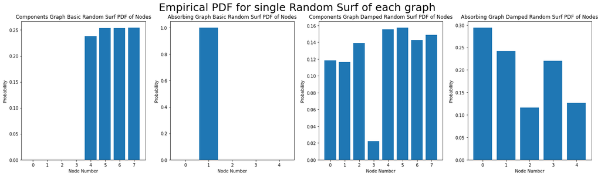

```python
fig, axes = plt.subplots(1, 4, figsize=(24, 6))
i = 0

plt.suptitle('Empirical PDF for single Random Surf of each graph', fontsize=25)

labels = [np.arange(8), np.arange(5)]

for key in random_surf_data:
    axes[i].bar(labels[i % 2], random_surf_data[key][2])
    axes[i].set_title(key + ' PDF of Nodes')
    axes[i].set_xlabel('Node Number')
    axes[i].set_ylabel('Probability')
    i += 1
```

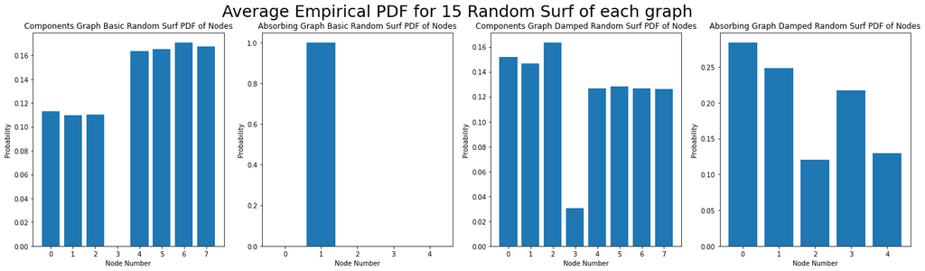

```python
fig, axes = plt.subplots(1, 4, figsize=(24, 6))
i = 0

plt.suptitle('Average Empirical PDF for 15 Random Surf of each graph', fontsize=25)

labels = [np.arange(8), np.arange(5)]

for key in random_surf_data:
    axes[i].bar(labels[i % 2], random_surf_data[key][0])
    axes[i].set_title(key + ' PDF of Nodes')
    axes[i].set_xlabel('Node Number')
    axes[i].set_ylabel('Probability')
    i += 1
```

### 2.4.2 Power Iteration Method

#### Exercise 2.14: Power Iteration method

```python
network_path = '../data/wikipedia.graph'
page_names_path = '../data/wikipedia_titles.tsv'
g = nx.read_adjlist(network_path, create_using=nx.DiGraph())

print('Number of nodes: ', g.number_of_nodes())
print('Number of edges: ', g.number_of_edges())

# database for page names
node_name_map = {}

with open(page_names_path) as tsv:
    tsv_file = csv.reader(tsv, dialect="excel-tab")
    next(tsv_file)
    for line in tsv_file:
        node_name_map[line[0]] = line[1]
```

```
Number of nodes:  5540
Number of edges:  197056
```

```python
def create_markov_matrix(H, g):
    """Populates the transition matrix of the Markov chain
    describing the random walk on the web graph
    """

    for i in range(g.order()):
        o_u = len(g.out_edges(str(i)))
        out_edges_of_node_i = [int(tpl[1]) for tpl in g.out_edges(str(i))]

        try:
            H[i, out_edges_of_node_i] = 1/o_u
        except:
            continue
    return H
```

```python
def fill_in_dangling_nodes(H):
    """If our random surfer arrives at a dangling node, we want it to
    continue surfing from a new webpage chosen uniformly at random
    """
    mask = np.all((H == 0), axis=1)
    H[mask] = 1 / H.shape[0]
    return H
```

```python
def add_random_restarts(H, theta):
    """At every iteration, flip a coin, with probability θ walk on Hˆ
    and with probability 1 − θ jump to a new random webpage.
    """
    uniform_matrix = np.ones((H.shape[0], H.shape[0])) * (1/H.shape[0])
    randomized_m = (theta*H) + (1-theta)*uniform_matrix
    return randomized_m
```

```python
def solve_pagerank(H):
    """Implementes Power Iteration Method until convergence
    """
    current_soln = np.ones((H.shape[0], H.shape[0])) * (1/H.shape[0])
    next_sol = np.matmul(current_soln, H)
    num_iter = 0

    diff = abs(np.sum(next_sol - current_soln))

    print(diff)

    while diff > 0.0000000000000001 and num_iter < 100 :
        current_soln = next_sol
        for i in range(5):
            next_sol = np.matmul(current_soln, H)
            current_soln = next_sol
            num_iter += 1
        next_sol = np.matmul(current_soln, H)
        diff = abs(np.sum(next_sol - current_soln))
        print("D(pi(k+1) - pi(k)) = " + str(diff))
        num_iter += 1

    return next_sol
```

```python
# Create transition matrix, populate it and apply power method.
H = np.zeros((g.order(), g.order()))
initial_m = create_markov_matrix(H, g)
filled_m = fill_in_dangling_nodes(initial_m)
randomized_m = add_random_restarts(filled_m, 0.15)
pagerank_m = solve_pagerank(randomized_m)
```

```
5.285346812988756e-12
D(pi(k+1) - pi(k)) = 3.147167856182298e-13
D(pi(k+1) - pi(k)) = 3.2209857610959736e-13
D(pi(k+1) - pi(k)) = 8.42641928455734e-15
D(pi(k+1) - pi(k)) = 9.307875650788056e-16
D(pi(k+1) - pi(k)) = 8.164042358815848e-16
D(pi(k+1) - pi(k)) = 1.6588293239028218e-16
D(pi(k+1) - pi(k)) = 7.058156142880634e-16
D(pi(k+1) - pi(k)) = 7.703256435509509e-16
D(pi(k+1) - pi(k)) = 1.0679391398982219e-16
D(pi(k+1) - pi(k)) = 0.0
```

```python
# calculate page rank order by summing along the columns of page rank matrix
page_rank_array = np.sum(pagerank_m, axis=0)
max_10 = np.argsort(page_rank_array)[:-11:-1]

print("Top 10 Pages Sorted in Page Rank Score:\n" + 60*"*")

for i in range(len(max_10)):
    print(f"{i + 1}.\t", node_name_map[str(max_10[i])], f'\t\t\tScore: {page_rank_array[max_10[i]]}')
```

```
Top 10 Pages Sorted in Page Rank Score:
1.	 United States 			Score: 10.229002207498567
2.	 United Kingdom 			Score: 7.197792692207753
3.	 England 			Score: 6.45652263874445
4.	 France 			Score: 5.964421257447191
5.	 Europe 			Score: 5.771775467114571
6.	 Biological classification 			Score: 5.447195847564357
7.	 Animal 			Score: 4.950219965465751
8.	 World War II 			Score: 4.767665661936514
9.	 London 			Score: 4.695291801414478
10.	 Germany 			Score: 4.689024278682574
```

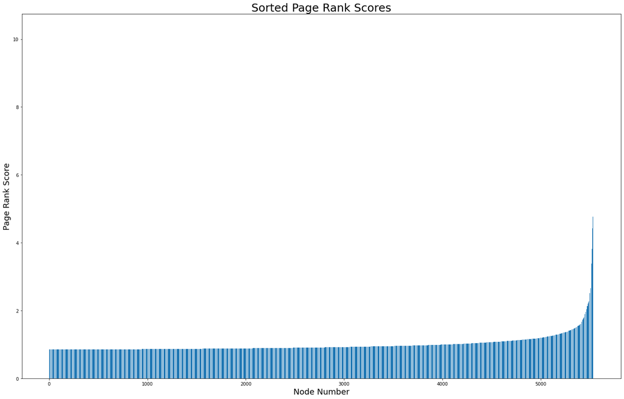

```python
plt.figure(figsize=(24, 15))
plt.title('Sorted Page Rank Scores', fontsize=25)

labels = [np.arange(5540)]
plt.bar(labels[0], np.sort(page_rank_array), width=0.7)
plt.xlabel('Node Number', fontsize=18)
plt.ylabel('Page Rank Score', fontsize=18)
```

### 2.4.3 Gaming the system *(Bonus)*

#### Exercise 2.15 *(Bonus)*

## Initial page rank of History of Mathematics

```python
for node, title in node_name_map.items():
    if title == 'History of mathematics':
        node_num = int(node)
```

```python
print(f"Node number of page \'History of mathematics\': {node_num}")
print(f"Page rank score of page \'History of mathematics\': {page_rank_array[node_num]}")
```

```
Node number of page 'History of mathematics': 2463
Page rank score of page 'History of mathematics': 0.8864489235916259
```

## Heuristics

With help of heuristics, we sort the pages in a score that ensembles both their initial calculated page rank and number of out degrees. If a page with a high page rank and low out degree point to the target page, it forwards most of the web page traffic to the target page.

## Proposed Algorithm

1. For each page calculate S = (1/(# of out degree)) * page_rank
2. Sort the pages descending order in S.
3. Point to History of mathematics from the first 300 pages in S

```python
# Populate matrix S
S = []
for i in range(len(page_rank_array)):
    denom = len(g.out_edges(str(i)))
    if denom != 0:
        S.append((i, page_rank_array[i] / denom))
    else:
        S.append((i, 0))
```

```python
S.sort(key=lambda x: x[1], reverse=True)
print(S)
```

[output not shown]

```python
# Point to the target page from the best 300 candidates.
for i in range(300):
    g.add_edge(str(S[i][0]), str(node_num))
```

```python
# Create transition matrix, populate it, then solve for it.
H = np.zeros((g.order(), g.order()))
initial_m = create_markov_matrix(H, g)
filled_m = fill_in_dangling_nodes(initial_m)
randomized_m = add_random_restarts(filled_m, 0.15)
pagerank_m = solve_pagerank(randomized_m)
```

```
5.2626045882187e-12
D(pi(k+1) - pi(k)) = 1.870366925574296e-12
D(pi(k+1) - pi(k)) = 8.126805435201834e-13
D(pi(k+1) - pi(k)) = 9.1063658350099e-13
D(pi(k+1) - pi(k)) = 1.2469008030951967e-12
D(pi(k+1) - pi(k)) = 6.654935933922412e-13
D(pi(k+1) - pi(k)) = 3.0243819601483146e-14
D(pi(k+1) - pi(k)) = 8.543513119185775e-16
D(pi(k+1) - pi(k)) = 1.0126448291014611e-15
D(pi(k+1) - pi(k)) = 5.5294310796760726e-17
```

```python
page_rank_array = np.sum(pagerank_m, axis=0)

print(f"Node number of page \'History of mathematics\': {node_num}")
print(f"Page rank score of page \'History of mathematics\': {page_rank_array[node_num]}")
```

```
Node number of page 'History of mathematics': 2463
Page rank score of page 'History of mathematics': 8.817742882021664
```

After boosting the page 'History of mathematics' with the proposed algorithm, a 10 fold increase in its page rank is observed.

# 0.88 -----------> 8.81